# MBOA metabolization by LMX9231 and LMB2 in shake flasks

Thoenen et al. BX SynComs

Christine Pestalozzi

2025-07-08

Metabolite samples were prepared as described before (Thoenen et al 2024, Nat Commun). Samples are quantified based on integrated peak areas (relative quantification only). (No standard curves available by mistake)

Read in the metadata

Read in the metabolite data (keep only data for compounds that were detected in at least one sample)

Combine the metadata and metabolite data

Colors for plotting etc

# Degradation of MBOA by LMX9231 in Erlenmeyer flasks

Medium at t0

Plot showing degradation of MBOA and production of AMPO and AAMPO by LMB2 and LMX9231 in shake flasks. Note that the AMP that is detected is in same range as for the DMSO control, hence not realiably detected. Therefore AMP is not shown. Compared to NBC, LMX9231 shows reduced MBOA after 3 days of incubation, revealing some degradation of MBOA is taking place. In LMB2 cultures, MBOA is no longer detected or close to the detection limit. In line with the MBOA measurements, more AMPO is detected in LMB2 than in LMX9231 samples. Please note that AMPO quantification can be tricky especially at high concentrations due to low solubility. Some AAMPO can be detected in LMX9231 samples (close to detection limit).

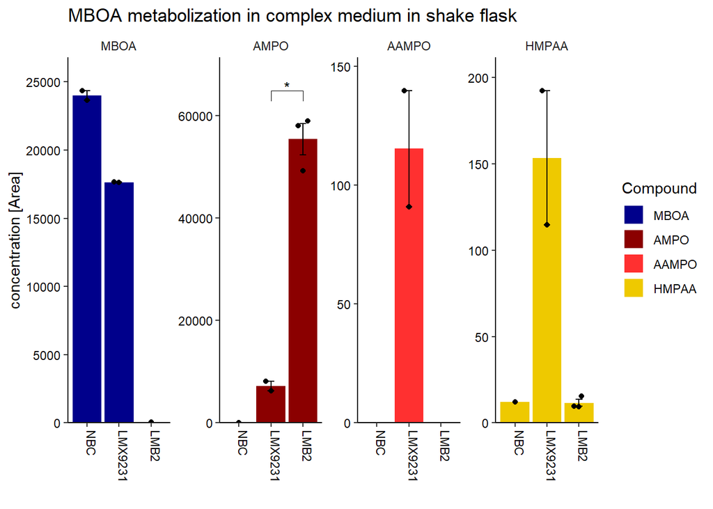

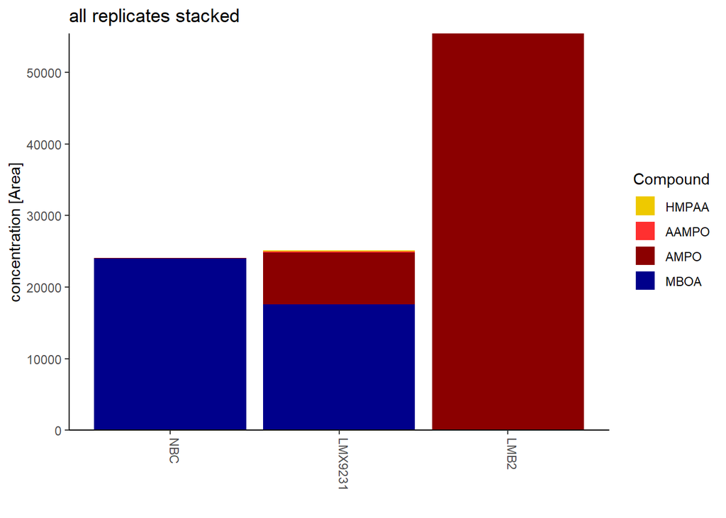